# Initial Setup

First we load the packages we will be needing.

```python
# for computation
import numpy as np
from scipy.integrate import odeint

# %matplotlib inline
import matplotlib.pyplot as plt

# for autocorrelation
import scipy.signal
```

We also define a function to visualise generated data in R3 that will be used for both the L63 and Roessler systems.

```python
def plot_states(sim_data):
    fig = plt.figure(facecolor="white")
    ax = plt.axes(projection="3d")
    ax.plot(
        sim_data[:, 0],     # all x components
        sim_data[:, 1],     # all y components
        sim_data[:, 2]      # all z components
    )
    plt.draw()
    plt.show()
```

# Lorenz-63 System

Recall that the Lorenz-63 system is defined as:

$$ \begin{align*} \dot{x} &= \sigma(y - x) \\ \dot{y} &= x(\rho - z) - y \\ \dot{z} &= xy - \beta z \end{align*} $$

where $\sigma,\,\rho,\,\beta \in \mathbb{R}$ are parameters and $(x,\,y,\,z) \in \mathbb{R}^3$.

### Generating Data

We define a function to generate data for the L63 system with the following default values for the parameters $$ (\sigma,\, \rho,\, \beta) = (10,\,28,\,\frac{8}{3}) $$ as used by Lorenz, and initial conditions: $$ (x_0,\,y_0,\,z_0) = (1,\,1,\,1). $$

Note that any set of parameters $(\sigma,\, \rho,\, \beta)$ and initial conditions $(x,\,y,\,z)$ can be used by simply passing their values into the data generation function.

For the default sampling time (`del_t`), we use $$\Delta t = 0.02$$ time units as used in Gottwald & Reich (2021).

`t_min` is an input that determines the point in time up to which the data will be "thrown away" to ensure that the particle has begun orbiting the attractor. Note that its default is 0, i.e. if needs to be explicitly specified. Note also that `t_min` should be given as a decimal, e.g. `t_min=0.5` represents throwing away the first half of values.

```python
# simulate for al ong time so it reaches the attractor, then start training.

def generate_lorenz_63(params=[10, 28, 8/3], initial_state=[1, 1, 1],
                        del_t=0.02, t_min=0, t_max=10):
    '''
    Input:      params:         parameters of the Lorenz-63 system
                initial_state:  initial spatial conditions (time t=0)
                del_t:          size of time increment
                t_min:          point in time up to which data will be thrown away, to ensure orbit around attractor
                t_max:          maximum time_value, which together with del_t determines the number of time increments (T)

    Output:     a (t_max / del_t)x3 matrix represented as a numpy.ndarray
    '''
    # get (sigma, rho, beta) from params vector
    sigma, rho, beta = params

    # helper function for computing derivatives at each time iteration
    def f(state, t):
        '''
        Input: state vector in R3
        Output: derivative vector in R3 for L63 with passed parameters
        '''

        # get (x, y, z) components of the state vector
        x, y, z = state

        # return the value of the derivatives
        return (
            sigma * (y - x),
            x * (rho - z) - y,
            x * y - beta * z
        )

    # define length of simulation (time), i.e. number of time increments
    T = np.arange(0, t_max, del_t)

    # integrate the system and return generated data
    all_data = odeint(func = f, y0 = initial_state, t = T)

    if t_min == 0:
        return all_data
    else:
        return all_data[int(t_min * len(T)):]
```

We test our code and expect some butterfly-like plot.

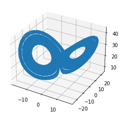

```python
lorenz_test_data = generate_lorenz_63(t_min=0.5, t_max=200)
plot_states(lorenz_test_data)
```

# Roessler System

Recall that the Roessler system in $\mathbb{R}^3$ is given by:

$$ \begin{align*} \dot{x} &= -y - z \\ \dot{y} &= x + ay \\ \dot{z} &= b + z(x - c) \end{align*} $$

where $a,\,b,\,c \in \mathbb{R}$ are parameters and $(x,\,y,\,z) \in \mathbb{R}^3$.

### Generating Data

We define a function to generate data for the Roessler system with the following default values for the parameters: $$ (a,\,b,\,c) = (0.2,\, 0.2,\, 5.7) $$ as used by Roessler, and initial conditions: $$ (x_0,\,y_0,\,z_0) = (1,\,1,\,1). $$ the default value.

As with the Lorenz function, any set of parameters $(a,\,b,\,c)$ and initial conditions $(x,\,y,\,z)$ can be used by simply passing their values into the data generation function.

For the default sampling time (`del_t`), we simply adopt $$ \Delta t = 0.02 $$ Further analysis will be done into finding a time increment such that the autocorrelation decay (see below) is as slow as possible while the system still exhibits chaotic properties.

`t_max` and `t_min` are defined same as above.

```python
def generate_roessler(params=[0.2, 0.2, 5.7], initial_state=[1, 1, 1],
                        del_t=0.02, t_min=0, t_max=10):
    '''
    Input:      params:         parameters of the Lorenz-63 system
                initial_state:  initial spatial conditions (time t=0)
                del_t:          size of time increment
                t_min:          point in time up to which data will be thrown away, to ensure orbit around attractor
                t_max:          maximum time_value, which together with del_t determines the number of time increments (T)

    Output:     a (t_max / del_t)x3 matrix represented as a numpy.ndarray
    '''

    # get (a, b, c) from params vector
    a, b, c = params

    # helper function for computing derivatives at each time iteration
    def f(state, t):
        '''
        Input: state vector in R3
        Output: derivative vector in R3 for L63 with passed parameters
        '''

        # get (x, y, z) components of the state vector
        x, y, z = state

        # return the value of the derivatives
        return (
            - y - z,
            x + a * y,
            b + z * (x - c)
        )

    # define length of simulation (time)
    T = np.arange(0, t_max, del_t)

    # integrate the system and return generated data
    all_data = odeint(func = f, y0 = initial_state, t = T)

    if t_min == 0:
        return all_data
    else:
        return all_data[int(t_min * len(T)):]
```

We test our code and expect the typical mountain peak plot.

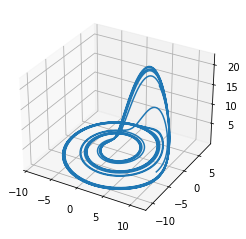

```python
roessler_test_data = generate_roessler(t_min=0.5, t_max=200)
plot_states(roessler_test_data)
```

# Autocorrelation

Now we plot the autocorrelation as a function of time delay size (denoted $l$) for both the L63 and Roessler systems.

Let $X$ denote our generated data (e.g. from the L63 or Roessler system), that is, $$ X = \begin{bmatrix} \mathbf{x}_0 \\ \mathbf{x}_1 \\ \vdots \\ \mathbf{x}_T \end{bmatrix} $$ is a $T \times 3$ matrix for some $T \in \mathbb{N}$ such that each row $\mathbf{x}_t = (x_t,\,y_t,\,z_t) \in \mathbb{R}^3$ represents a state vector at time $t \in [0, T] \cap \mathbb{N}$.

Then the autocorrelation of $X$ as a function of some time delay $l \in [0, T]$ in the $x$-$y$ domain is defined as: $$ R_{xy}(l) = \sum_{t=0}^{T} (x_{t} - \bar{x})(y_{t - l} - \bar{x}). $$ and similar definitions for $R_{xz},\,R_{xx},\,\dots$ etc.

Note that we dropped the conjugate operator since our state vectors are in $\mathbb{R}^3$. Note also that we pad the lagged series with zeroes, that is, $$ x_{t - l} = \begin{cases} x_{t - l} &\quad\text{if $t \geq l$} \\ 0 &\quad\text{otherwise} \end{cases} $$

```python
def compute_acf(data, axis1, axis2, l):
    '''
    Inputs:     data:   Tx3 matrix generated from odeint, e.g. l63 or roessler
                axis1:  (str) spatial dimension of first time series (i.e. x, y, or z)
                axis2:  (str) spatial dimension of second time series (i.e. x, y, or z)
                l:      (float) time delay, 0 < l < data.shape[0]

    Output:     real number, representing autocorrelation between axis1 and
                axis2 for the given time lag value (l)
    '''
    def parse_axis(axis):
        if axis == "x":
            return 0
        elif axis == "y":
            return 1
        else:
            return 2

    # obtain parameter values
    T = data.shape[0]       # number of time increments

    # get the two spatial dimensions we are comparing correlations
    # get series1 (non-lagged)
    series1 = data[:, parse_axis(axis1)]
    # subtract mean from series1
    series1 = series1 - np.mean(series1)

    # set up zero matrix
    series2 = np.zeros(series1.shape)
    # # obtain mean for series2
    mean_2 = np.mean(data[:, parse_axis(axis2)])
    # # apply zero-padded time lag for series2 (for given l) and subtract mean
    for i in range(l, len(series2), 1):
        series2[i] = data[:, parse_axis(axis2)][i - l] - mean_2

    # compute autocorrelation value for given l
    return np.dot(series1, series2)
```

We test our acf function works as expected on some simple cases.

```python
# test data
acf_test_data = np.array([
    [1, 2, 3],
    [4, 6, 8],
    [9, 11, 13],
    [14, 15, 16],
    [17, 19, 21]
])

print("Autocorrelation in the x-y domain, with l=2")
print("Actual: {}".format(compute_acf(acf_test_data, "x", "y", 2)))
print("---")
# # expected behaviour
print("Expect: {}".format(np.dot(
    [1, 4, 9, 14, 17] - np.mean([1, 4, 9, 14, 17]),
    [np.mean([2, 6, 11, 15, 19]), np.mean([2, 6, 11, 15, 19]), 2, 6, 11] - np.mean([2, 6, 11, 15, 19])
)))

print("\nAutocorrelation in the z-z domain, with l=2")
# compute acf in z-z domain, with l=2
print("Actual: {}".format(compute_acf(acf_test_data, "z", "z", 2)))
print("---")
# expected behaviour
print("Expect: {}".format(np.dot(
    [3, 8, 13, 16, 21] - np.mean([3, 8, 13, 16, 21]),
    [np.mean([3, 8, 13, 16, 21]), np.mean([3, 8, 13, 16, 21]), 3, 8, 13] - np.mean([3, 8, 13, 16, 21])
)))

# expected behaviour
```

```
Autocorrelation in the x-y domain, with l=2
Actual: -19.799999999999997
---
Expect: -19.799999999999997

Autocorrelation in the z-z domain, with l=2
Actual: -16.28
---
Expect: -16.28
```

Now we define a function which plots the autocorrelation in all six domains as a function of $l$ $(R_{xx},\, R_{xy},\, R_{xz},\, R_{yy},\, R_{yz},\, R_{zz})$ for any given data (e.g. L63, Roessler).

```python
def plot_acf(data, title=""):
    '''
    Inputs:     data:   Tx3 matrix generated from odeint, e.g. l63 or roessler
    Output:     None
    '''

    fig = plt.figure(facecolor="white")
    ax = plt.axes()
    ax.set_ylabel("Autocorrelation")
    ax.set_xlabel("Size of Time Delay (l)")
    if len(title) == 0:
        ax.set_title("Autocorrelation")
    else:
        ax.set_title("Autocorrelation of " + title)

    spatial_dims = ["x", "y", "z"]
    l_vals = range(0, data.shape[0], 1)

    i = 0
    while i < len(spatial_dims):
        j = i
        while j < len(spatial_dims):
            axis1 = spatial_dims[i]
            axis2 = spatial_dims[j]

            y_vals = [compute_acf(data, axis1, axis2, l) for l in range(0, data.shape[0], 1)]

            ax.plot(l_vals, y_vals, label=axis1+axis2)

            j += 1

        i += 1

    plt.draw()
    plt.legend()
    plt.show()
```

We test our function on `lorenz_test_data` and `roessler_test_data`.

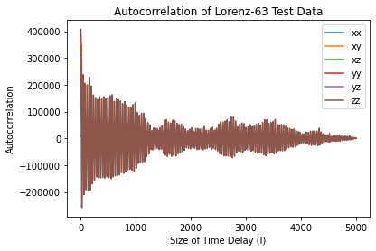

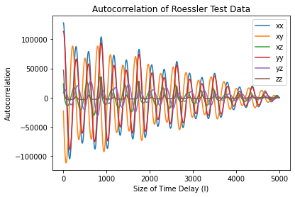

```python
# compute_acf(lorenz_test_data, "x", "x", 2)

plot_acf(lorenz_test_data, "Lorenz-63 Test Data")
plot_acf(roessler_test_data, "Roessler Test Data")
```

As expected, the autocorrelation of the Roessler system decays much more slowly than that of the Lorenz-63 system.

The code below is used to export this notebook to HTML.

```python
# export notebook
import os

os.system('jupyter nbconvert --to html data-generation.ipynb')
```

```
[NbConvertApp] Converting notebook data-generation.ipynb to html
[NbConvertApp] Writing 809889 bytes to data-generation.html
```

```
0
```